# Homework 01

## Question 1 (Least squares and matrix calculations)

Set the random seed to 43201. Generate $n=100$ observations with $p=5$ predictors according to

$$x_{ij}\overset{\mathrm{iid}}{\sim}N(0,1),
\qquad
\varepsilon_i\overset{\mathrm{iid}}{\sim}N(0,0.7^2),$$

with all predictors and errors generated independently. Let

$$\mathbf X
=
\begin{bmatrix}
\mathbf 1 & \mathbf x_1 & \cdots & \mathbf x_5
\end{bmatrix},
\qquad
\boldsymbol\beta
=
(3,1.4,-0.9,0.7,0,1.1)^{\mathsf T},$$

and generate

$$\mathbf y=\mathbf X\boldsymbol\beta+\boldsymbol\varepsilon.$$

```python
import numpy as np
import pandas as pd

rng = np.random.default_rng(43201)
beta = np.array([3.0, 1.4, -0.9, 0.7, 0.0, 1.1])
X = np.column_stack([np.ones(100), rng.normal(0.0, 1.0, size=(100, 5))])
epsilon = rng.normal(0.0, 0.7, size=100)
y = X @ beta + epsilon
```

1. Generate the data and report the dimensions and rank of $\mathbf X$. Calculate the least-squares estimate $\widehat{\boldsymbol\beta}$ using a numerically stable least-squares routine, without explicitly calculating $(\mathbf X^{\mathsf T}\mathbf X)^{-1}$. Compare the estimates with the coefficients used to generate the data.

```python
print("dim(X) = ", X.shape)
print("rank(X) = ", np.linalg.matrix_rank(X))
```

```
dim(X) =  (100, 6)
rank(X) =  6
```

$\mathbf X$ is $100 \times 6$ with rank 6, so it has full column rank and the least-squares solution is unique. `np.linalg.lstsq` uses an SVD-based solver; QR is a second stable route that back-solves $\mathbf R\widehat{\boldsymbol\beta} = \mathbf Q^{\mathsf T}\mathbf y$. Neither forms $(\mathbf X^{\mathsf T}\mathbf X)^{-1}$.

```python
beta_hat = np.linalg.lstsq(X, y, rcond=None)[0]
Q, R = np.linalg.qr(X)
beta_hat_qr = np.linalg.solve(R, Q.T @ y)
print("max |lstsq - qr| = ", np.max(np.abs(beta_hat - beta_hat_qr)))
```

```
max |lstsq - qr| =  1.4765966227514582e-14
```

The two routes agree to about $10^{-14}$.

```python
r = y - X @ beta_hat
s2 = np.sum(r ** 2) / (100 - X.shape[1])
Rinverse = np.linalg.inv(R)
se = np.sqrt(s2 * np.diag(Rinverse @ Rinverse.T))
pd.DataFrame({"true": beta, "estimate": beta_hat.round(4),
              "diff/SE": ((beta_hat - beta) / se).round(2)})
```

|  | true | estimate | diff/SE |
| --- | --- | --- | --- |
| 0 | 3.0 | 2.9731 | -0.39 |
| 1 | 1.4 | 1.3240 | -1.05 |
| 2 | -0.9 | -0.8415 | 0.99 |
| 3 | 0.7 | 0.7204 | 0.30 |
| 4 | 0.0 | -0.0831 | -1.29 |
| 5 | 1.1 | 1.1651 | 1.01 |

Every estimate is within 1.3 standard errors of the value used to generate the data, which is what we expect with $n = 100$ and $\sigma = 0.7$. The irrelevant predictor $x_4$ has true coefficient 0 but is estimated at $-0.083$, since least squares applies no shrinkage; its size is on the order of its standard error.

2. Calculate the fitted values, the residual vector $\mathbf r=\mathbf y-\mathbf X\widehat{\boldsymbol\beta}$, and the training root mean squared error

$$\operatorname{RMSE}
=
\left(
\frac{1}{n}\sum_{i=1}^{n}r_i^2
\right)^{1/2}.$$

```python
fitted = X @ beta_hat
r = y - fitted
print("rmse =", round(np.sqrt(np.mean(r ** 2)), 4))
print("sigma_hat =", round(np.sqrt(np.sum(r ** 2) / (100 - 6)), 4))
```

```
rmse = 0.6463
sigma_hat = 0.6666
```

The training RMSE is $0.6463$, slightly below the true $\sigma = 0.7$. Dividing by $n$ rather than the residual degrees of freedom $n - 6$ biases the estimate downward; the unbiased version $\widehat\sigma = 0.6666$ is closer.

```python
print(np.max(np.abs(X.T @ r)))
```

```
1.485143451574447e-12
```

## Question 2 (Gaussian likelihood for linear regression)

Continue with the data from Question 1. Suppose

$$\mathbf Y\mid\mathbf X
\sim
N_n\left(\mathbf X\boldsymbol\beta,\sigma^2\mathbf I_n\right).$$

The log-likelihood, including the constant term, is

$$\ell(\boldsymbol\beta,\sigma^2)
=
-\frac{n}{2}\log(2\pi\sigma^2)
-\frac{1}{2\sigma^2}
(\mathbf y-\mathbf X\boldsymbol\beta)^{\mathsf T}
(\mathbf y-\mathbf X\boldsymbol\beta).$$

1. For fixed $\sigma^2$, explain why maximizing $\ell(\boldsymbol\beta,\sigma^2)$ over $\boldsymbol\beta$ is equivalent to minimizing the residual sum of squares. What does this imply about the maximum-likelihood estimate of $\boldsymbol\beta$?

Write $\operatorname{RSS}(\boldsymbol\beta)=\lVert\mathbf y-\mathbf X\boldsymbol\beta\rVert_2^2$, so $\ell = -\frac{n}{2}\log(2\pi\sigma^2) - \operatorname{RSS}(\boldsymbol\beta)/(2\sigma^2)$. With $\sigma^2$ held fixed the first term is a constant and the multiplier $-1/(2\sigma^2)$ is strictly negative, so $\ell$ is a strictly decreasing affine function of $\operatorname{RSS}$. Maximizing one is the same as minimizing the other.

So the MLE of $\boldsymbol\beta$ is exactly the least-squares estimate from Question 1. The value of $\sigma^2$ never enters the argmin.

2. For fixed $\boldsymbol\beta$, differentiate the log-likelihood with respect to $\sigma^2$ and derive its maximum-likelihood estimate. Calculate this estimate at $\widehat{\boldsymbol\beta}$ and compare it with the unbiased estimate of $\sigma^2$. Explain why the two denominators differ.

Let $v=\sigma^2$ with $\boldsymbol\beta$ fixed, so $\ell = -\frac{n}{2}\log(2\pi v) - \operatorname{RSS}/(2v)$ and $\partial\ell/\partial v = -n/(2v) + \operatorname{RSS}/(2v^2)$. Setting this to zero gives $\widehat\sigma^2_{\mathrm{MLE}} = \operatorname{RSS}/n$, and the second derivative there is $-n/(2\widehat v^2) < 0$, confirming a maximum. The usual unbiased estimate divides by $n-6$ instead.

```python
rss = r @ r
sigma2_mle = rss / 100
sigma2_unbiased = rss / (100 - X.shape[1])
print("rss =", round(rss, 4))
print("mle =", round(sigma2_mle, 6))
print("unbiased =", round(sigma2_unbiased, 6))
```

```
rss = 41.7755
mle = 0.417755
unbiased = 0.44442
```

The MLE is $0.4178$ and the unbiased estimate is $0.4444$, against a true $\sigma^2 = 0.49$. The denominators differ because $\mathbf r$ was built from $\widehat{\boldsymbol\beta}$ rather than $\boldsymbol\beta$, so it lives in an $(n-6)$-dimensional subspace and $\mathbb E(\operatorname{RSS}) = (n-6)\sigma^2$. Dividing by $n$ therefore understates $\sigma^2$ by the factor $(n-6)/n = 0.94$. The MLE is consistent, so the gap closes as $n$ grows.

3. Let

$$\mathbf e_{x_2}=(0,0,1,0,0,0)^{\mathsf T}.$$

Using the variance estimate from part b, plot

$$\ell\left(
\widehat{\boldsymbol\beta}+t\mathbf e_{x_2},
\widehat{\sigma}_{\mathrm{MLE}}^2
\right)$$

over a grid of $t$ values from $-1.25$ to $1.25$. State where the maximum occurs and explain why this agrees with the least-squares result.

```
maximizing t= 0.0
```

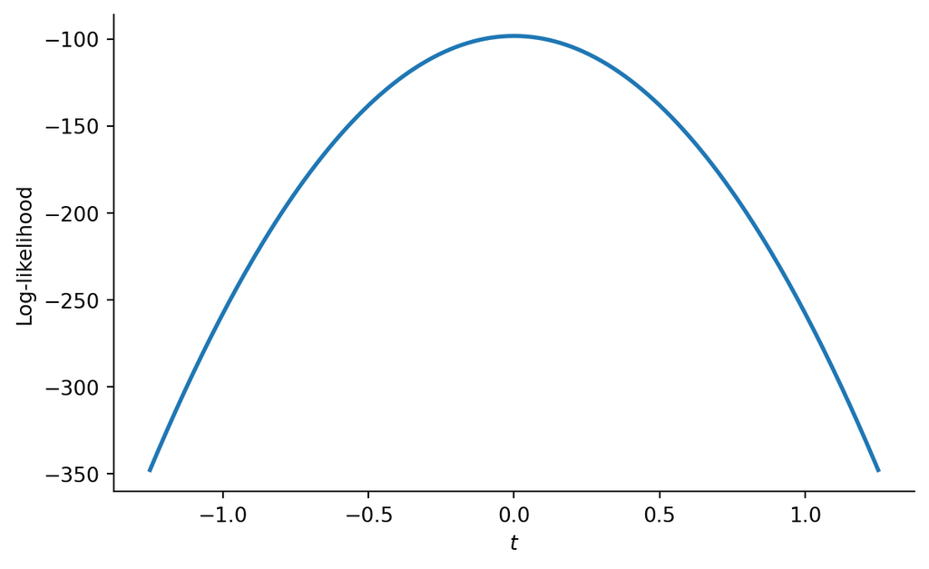

```python
import matplotlib.pyplot as plt
def log_likelihood(b, sigma2):
    residual = y - X @ b
    return -100 / 2 * np.log(2 * np.pi * sigma2) - residual @ residual / (2 * sigma2)

e_x2 = np.array([0.0, 0.0, 1.0, 0.0, 0.0, 0.0])
t_grid = np.linspace(-1.25, 1.25, 251)
profile = np.array([log_likelihood(beta_hat + t * e_x2, sigma2_mle) for t in t_grid])
print("maximizing t=", t_grid[np.argmax(profile)])
fig, ax = plt.subplots(figsize=(7, 4.2))
ax.plot(t_grid, profile, linewidth=2)
ax.set(xlabel=r"$t$", ylabel="Log-likelihood")
ax.spines[["top", "right"]].set_visible(False)
plt.show()
```

The maximum is at $t=0$, which is $\widehat{\boldsymbol\beta}$ itself. This is forced by the orthogonality result from 1(c). Perturbing along $\mathbf e_{x_2}$ makes the residual $\mathbf r - t\mathbf x_2$, so

$$\operatorname{RSS}(\widehat{\boldsymbol\beta}+t\mathbf e_{x_2})
= \operatorname{RSS} - 2t\,\mathbf x_2^{\mathsf T}\mathbf r + t^{2}\lVert\mathbf x_2\rVert_2^{2}
= \operatorname{RSS} + t^{2}\lVert\mathbf x_2\rVert_2^{2},$$

because $\mathbf x_2^{\mathsf T}\mathbf r = 0$. The cross term vanishes, leaving an exact downward parabola centered at zero. Since $\sigma^2$ only rescales the curve, the location of the maximum does not depend on which variance estimate is used. This is part (a) restated: the likelihood maximizer is the least-squares solution.

## Question 3 (Starting values in nonconvex optimization)

Consider the function

$$f(x)=\exp(1.5x)-3(x+6)^2-0.05x^3,$$

with derivative

$$f'(x)=1.5\exp(1.5x)-6(x+6)-0.15x^2.$$

1. Plot $f(x)$ over the interval $[-40,7]$. Based on the plot, describe the important features of the objective function that may affect numerical optimization.

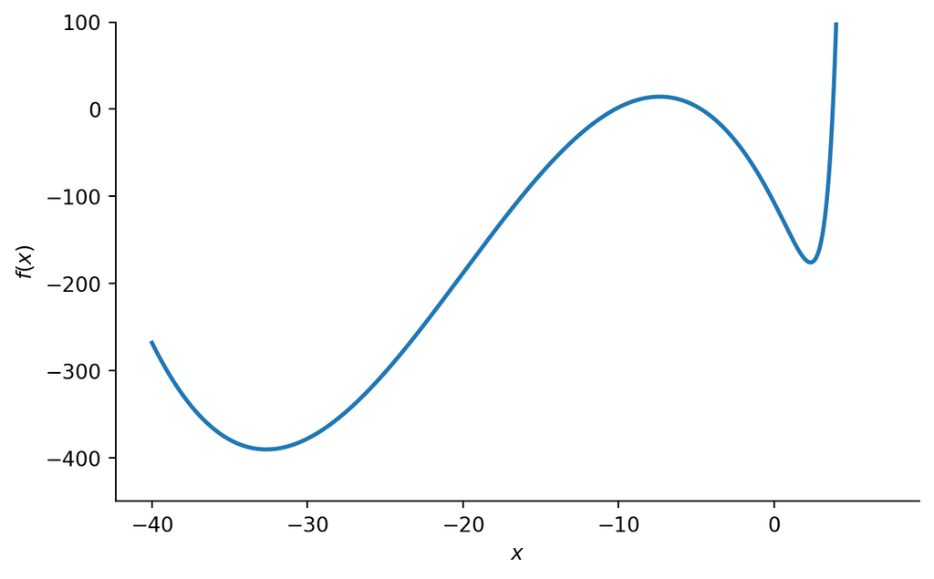

```python
from scipy.optimize import minimize, brentq
def objective(x):
    return np.exp(1.5 * x) - 3 * (x + 6) ** 2 - 0.05 * x ** 3

def gradient(x):
    return 1.5 * np.exp(1.5 * x) - 6 * (x + 6) - 0.15 * x ** 2

x_grid = np.linspace(-40, 7, 1200)
fig, ax = plt.subplots(figsize=(7, 4.2))
ax.plot(x_grid, objective(x_grid), linewidth=2)
ax.set(ylim=(-450, 100), xlabel=r"$x$", ylabel=r"$f(x)$")
ax.spines[["top", "right"]].set_visible(False)
plt.show()
```

The function is nonconvex with two local minima separated by a local maximum near $x=-7.35$. Each minimum has its own basin of attraction, and BFGS only uses local gradient information, so which minimum it returns is determined by which basin the starting value falls in.

The scale is also badly unbalanced. The exponential term is numerically dead on the left half of the interval but reaches about $3.6\times10^{4}$ at $x=7$, against a minimum of $-390$, so the vertical axis is clipped to keep both minima visible. Curvature therefore varies enormously across the domain, and a start much to the right of $x=7$ risks overflow or wildly overlong first steps.

2. Use BFGS to minimize $f(x)$ twice, starting at $x^{(0)}=-15$ and $x^{(0)}=0$. Supply $f'(x)$ to the optimizer. For each run, report the final value of $x$, the final objective value, $|f'(x)|$, and whether the optimizer reported convergence.

```python
results = []
for start in [-15.0, 0.0]:
    res = minimize(fun=lambda v: objective(v[0]), x0=np.array([start]), jac=lambda v: np.array([gradient(v[0])]), method="BFGS")
    results.append(res)
    print(f"start={start:6.1f} x={res.x[0]: .6f} f(x)={res.fun: .6f} " f"|f'(x)|={abs(gradient(res.x[0])):.2e} converged={res.success}")
```

```
start= -15.0 x=-32.649111 f(x)=-390.385770 |f'(x)|=2.84e-14 converged=True
start=   0.0 x= 2.349967 f(x)=-175.862620 |f'(x)|=8.13e-06 converged=True
```

| $x^{(0)}$ | final $x$ | $f(x)$ | $\lvert f'(x)\rvert$ | converged |
| --- | --- | --- | --- | --- |
| $-15$ | $-32.649111$ | $-390.385770$ | $2.8\times10^{-14}$ | yes |
| $0$ | $2.349967$ | $-175.862620$ | $8.1\times10^{-6}$ | yes |

3. Explain why the two runs can converge to different answers. Which run gives the lower objective value? What additional evidence would be needed before claiming that this point is the global minimum?

The two runs land in different basins. At $x=-15$ the gradient is $20.25>0$, so the first step moves left and the iterates descend into the left basin. At $x=0$ the gradient is $-34.5<0$, the first step moves right, and the local maximum at $x\approx-7.35$ sits between the start and the left minimum, blocking any path to it. Both runs report convergence with essentially zero gradient, which confirms each found a local minimum and says nothing about global optimality.

The run from $-15$ gives the lower value, $-390.386$ against $-175.863$. Claiming it is the global minimum needs evidence that nothing lower exists anywhere, which the two runs cannot supply. In one dimension that means the limiting behavior of $f$ plus a full accounting of its stationary points.

```python
grid = np.linspace(-60, 7, 200001)
values = gradient(grid)
roots = [brentq(gradient, grid[i], grid[i+1]) for i in range(len(grid) - 1) if values[i] * values[i+1] < 0]
for z in roots:
    print(f"x={z: .6f} f(x)={objective(z): .6f}")
print("f(-60) =", objective(-60.0), "  f(7) =", round(objective(7.0), 2))
```

```
x=-32.649111 f(x)=-390.385770
x=-7.350883 f(x)= 14.385787
x= 2.349967 f(x)=-175.862620
f(-60) = 2052.0   f(7) = 35791.35
```

As $x\to+\infty$ the exponential dominates and $f\to+\infty$; as $x\to-\infty$ the $-0.05x^3$ term dominates and again $f\to+\infty$, so a global minimum exists at a stationary point. A sign-change sweep of $f'$ finds exactly three: minima at $-32.649$ and $2.350$, and the local maximum at $-7.351$. Comparing $f$ across them puts the global minimum at $x=-32.649$. This is strong evidence, not proof, since a grid sweep would miss a tangential root or a root pair falling between adjacent grid points, and the interval was truncated at $-60$ rather than handled analytically.

## Question 4 (Nearly collinear predictors)

Continue with $\mathbf X$ and $\mathbf y$ from Question 1. Set the random seed to 43202 and generate

$$u_i\overset{\mathrm{iid}}{\sim}N(0,1),
\qquad i=1,\ldots,n.$$

Define

$$\mathbf x_6=\mathbf x_1+10^{-4}\mathbf u,
\qquad
\mathbf X_+
=
\begin{bmatrix}
\mathbf X & \mathbf x_6
\end{bmatrix},$$

and let

$$\mathbf y^\star=\mathbf y+10^{-3}\mathbf u.$$

Use a numerically stable least-squares routine throughout.

1. Fit $\mathbf y$ using $\mathbf X$ and $\mathbf X_+$. For each design matrix, report the condition number and training RMSE. For the augmented fit, also report the coefficients of $\mathbf x_1$ and $\mathbf x_6$.

```python
rng_q4 = np.random.default_rng(43202)
u = rng_q4.normal(size=100)
x6 = X[:, 1] + 1e-4 * u
X_plus = np.column_stack([X, x6])
y_star = y + 1e-3 * u
beta_original = np.linalg.lstsq(X, y, rcond=None)[0]
beta_augmented = np.linalg.lstsq(X_plus, y, rcond=None)[0]
beta_perturbed = np.linalg.lstsq(X_plus, y_star, rcond=None)[0]

fitted_original = X @ beta_original
fitted_augmented = X_plus @ beta_augmented
fitted_perturbed = X_plus @ beta_perturbed

pd.DataFrame({"design": ["X", "X_plus"], "condition_number": [np.linalg.cond(X), np.linalg.cond(X_plus)], "training_rmse": [np.sqrt(np.mean((y - fitted_original) ** 2)), np.sqrt(np.mean((y - fitted_augmented) ** 2))]})
```

|  | design | condition_number | training_rmse |
| --- | --- | --- | --- |
| 0 | X | 1.452504 | 0.646340 |
| 1 | X_plus | 20339.835807 | 0.633956 |

```python
print("beta_x1, beta_x6 =", beta_augmented[[1, 6]], " sum =", beta_augmented[[1, 6]].sum())
```

```
beta_x1, beta_x6 = [-1329.74301559  1331.06013906]  sum = 1.3171234629962782
```

The condition number jumps from $1.45$ to about $2.0\times10^{4}$ while the training RMSE barely moves, $0.6463$ to $0.6340$. The individual coefficients are the story: $\widehat\beta_1=-1329.74$ and $\widehat\beta_6=1331.06$, enormous and nearly cancelling, with sum $1.317$ against $\widehat\beta_1=1.324$ from the original fit. The data pin down the combined contribution of the two columns and say almost nothing about how to split it.

2. Fit $\mathbf y^\star$ using $\mathbf X_+$. Report the changes in the coefficients of $\mathbf x_1$ and $\mathbf x_6$. Compare the two fitted-value vectors using their root mean squared difference and maximum absolute difference.

```python
coefficient_change = (beta_perturbed - beta_augmented)[[1, 6]]
fitted_difference = fitted_perturbed - fitted_augmented

print("change in (beta_x1, beta_x6) =", coefficient_change)
print("largest other coefficient change =", np.max(np.abs((beta_perturbed - beta_augmented)[[0, 2, 3, 4, 5]])))
print("fitted RMS difference =", np.sqrt(np.mean(fitted_difference ** 2)))
print("fitted max difference =", np.max(np.abs(fitted_difference)))
```

```
change in (beta_x1, beta_x6) = [-10.  10.]
largest other coefficient change = 5.280081927239166e-13
fitted RMS difference = 0.0009749802939436066
fitted max difference = 0.0023511653220102957
```

The two coefficients move by exactly $-10$ and $+10$, every other coefficient is unchanged to machine precision, and the fitted values move by an RMS of $0.000975$ with a maximum of $0.00235$. A change of size 10 in the coefficients produces a change of size $10^{-3}$ in the predictions.

3. Use the identity

$$\mathbf y^\star-\mathbf y
=
10(\mathbf x_6-\mathbf x_1)$$

to explain why the fitted values change very little while the two coefficients change substantially. What does this example suggest about interpreting separate effects for nearly collinear predictors?

By construction $\mathbf x_6-\mathbf x_1=10^{-4}\mathbf u$, so $\mathbf u = 10^{4}(\mathbf x_6-\mathbf x_1)$ and $\mathbf y^\star-\mathbf y = 10^{-3}\mathbf u = 10(\mathbf x_6-\mathbf x_1)$. The perturbation therefore lies exactly in the column space of $\mathbf X_+$, along the direction $\mathbf d$ with $d_1=-10$, $d_6=+10$ and zeros elsewhere. Least squares is a linear projection, so the perturbed fit is the old fit plus the perturbation itself, giving exactly the $(-10,+10)$ observed above with no other coefficient touched.

The asymmetry comes from the length of that direction. In coefficient space $\mathbf d$ has norm $10\sqrt2\approx14.1$, but $\mathbf X_+\mathbf d = 10^{-3}\mathbf u$ has entries around a thousandth, because $\mathbf X_+$ crushes this direction by a factor of $10^{4}$. That is what a condition number of $2\times10^{4}$ means: coefficients can travel a long way along it at almost no cost in fit.

The lesson is that predictions and separate effects are identified very differently. The fitted values and the sum $\widehat\beta_1+\widehat\beta_6$ are stable; the individual coefficients are not, and their sign and magnitude here are an artifact of one noise draw. With nearly collinear predictors, reporting the effect of $x_1$ holding $x_6$ fixed reports something the data cannot resolve, since that is exactly the direction the design cannot see.

## Question 5 (Data preparation and summary statistics)

The file `data/data-manipulation.csv` is a small constructed data table containing an observation identifier, a group label, two numeric predictors, and a response. Some response values are missing. For analyses involving the response, use only observations with a recorded response. Do not replace a missing response with zero or a group mean.

1. Read the data and report its dimensions, column types, number of duplicated identifiers, and number of missing values in each column. Create an analysis table containing only observations with a recorded response, and define

$$\texttt{feature\_sum}=\texttt{x1}+\texttt{x2}.$$

```python
import os
from pathlib import Path
data_file = Path("data") / "data-manipulation.csv"
if not data_file.exists():
    document_dir = Path(os.environ.get("QUARTO_DOCUMENT_PATH", "."))
    data_file = document_dir / "data" / "data-manipulation.csv"
small_data = pd.read_csv(data_file)

print("dimensions:", small_data.shape)
print(small_data.dtypes)
print("duplicated identifiers:", small_data["observation_id"].duplicated().sum())
print(small_data.isna().sum())
```

```
dimensions: (24, 5)
observation_id        str
group                 str
x1                float64
x2                float64
response          float64
dtype: object
duplicated identifiers: 0
observation_id    0
group             0
x1                0
x2                0
response          3
dtype: int64
```

```python
analysis_data = small_data.dropna(subset=["response"]).copy()
analysis_data["feature_sum"] = analysis_data["x1"] + analysis_data["x2"]
print("rows retained:", len(analysis_data))
```

```
rows retained: 21
```

The table has 24 rows and 5 columns. `observation_id` and `group` are text; `x1`, `x2`, and `response` are numeric. There are no duplicated identifiers. Only `response` has missing values, 3 of them, leaving 21 observations in the analysis table. Those rows are dropped rather than filled, since substituting zero would insert a value that was never observed and substituting a group mean would understate variability.

2. For each group, report the number of observations, the mean response, and the mean of `feature_sum`. State clearly which observations these summaries describe.

```python
group_summary = analysis_data.groupby("group", as_index=False).agg(
    observations=("response", "size"),
    mean_response=("response", "mean"),
    mean_feature_sum=("feature_sum", "mean"),
)
group_summary.round(4)
```

|  | group | observations | mean_response | mean_feature_sum |
| --- | --- | --- | --- | --- |
| 0 | A | 7 | 5.6000 | 3.6000 |
| 1 | B | 7 | 7.6029 | 4.9286 |
| 2 | C | 7 | 7.9971 | 6.5857 |

These summaries describe only the 21 observations with a recorded response, not all 24 rows, so the group counts are counts of responding observations within each group.

3. Sort the analysis table by response from largest to smallest and report the first three rows, including `observation_id`, `group`, `response`, and `feature_sum`. Add code checks verifying that the number of retained rows equals the number of nonmissing responses in the original data, that the analysis table has no missing response values, and that its identifiers are unique.

```python
largest_three = (
    analysis_data
    .sort_values("response", ascending=False)
    .loc[:, ["observation_id", "group", "response", "feature_sum"]]
    .head(3)
)
largest_three
```

|  | observation_id | group | response | feature_sum |
| --- | --- | --- | --- | --- |
| 21 | obs-22 | C | 9.24 | 6.6 |
| 15 | obs-16 | B | 9.00 | 5.2 |
| 13 | obs-14 | B | 8.66 | 5.0 |

```python
number_recorded = small_data["response"].notna().sum()
assert len(analysis_data) == number_recorded
assert not analysis_data["response"].isna().any()
assert analysis_data["observation_id"].is_unique
print("all checks passed")
```

```
all checks passed
```

The checks are written against `number_recorded` computed from the original table rather than a hard-coded 21, so they still hold if the underlying file changes.

## Question 6 (Can 39 million Fitbit records represent US adults?)

[Patten et al. (2026)](https://doi.org/10.1038/s41591-026-04352-3) describe Fitbit data from 59,018 participants in the All of Us Research Program. The dataset spans 14 years and contains more than 39 million daily step records. Participants contributed data through one of two routes:

- Bring Your Own Device (BYOD): participants shared data from a Fitbit they already owned.
- Wearables Enhancing All of Us Research (WEAR): invited participants received a Fitbit at no cost.

In the general activity cohort, the BYOD and WEAR groups contained 32,035 and 22,474 participants, respectively. The BYOD value is listed first in each comparison below:

- 77.3% versus 55.1% reported being White;
- 6.1% versus 15.2% reported annual household income between $\$10{,}000$ and $\$25{,}000$; and
- median daily steps were 6,867 versus 5,797.

Suppose the target is the mean of the participant-specific average daily step counts among US adults during the study period, with each adult given equal weight. A researcher writes:

> “This dataset contains more than 39 million daily Fitbit records. Therefore, the average of all recorded step counts should provide an accurate estimate of mean daily activity among US adults.”
1. Are the 39 million daily records independent observations? What characteristics or behaviors could cause some participants to contribute more recorded days than others? Explain how averaging all recorded days would then weight participants unequally.

No. They are repeated measurements on roughly 59,000 people, averaging several hundred days each. Days from the same person are correlated because the drivers of step counts persist: occupation, commute, health status, neighborhood walkability, and habit. The number of genuinely independent units is closer to 59,018 than to 39 million, so treating the records as independent draws would badly understate standard errors. Participants are the sampling units, and the within-person dependence has to be modeled or removed by summarizing within person first.

Participants also contribute very different numbers of days. More days come from longer enrollment, consistent wear, reliable syncing, and a compatible smartphone; fewer come from illness, travel, irregular shift work, losing interest, hardware failure, and days excluded by the study’s minimum wear-time rule.

The average over all recorded days is therefore a record-weighted mean: a participant with 2,000 valid days counts twenty times as heavily as one with 100. The stated target weights each adult equally. The two coincide only if day count is unrelated to activity, which is implausible, since the engagement and health that produce consistent wear plausibly go with higher step counts, and low-activity days are the ones most likely to fail a wear-time filter.

2. BYOD participants reported a median of 6,867 daily steps, compared with 5,797 among WEAR participants. Does this comparison show that already owning a Fitbit causes people to walk more? Explain your answer and give at least one plausible alternative explanation based on how participants entered the two groups.

No. Participants were not randomized to the two routes; they selected into them, and BYOD membership requires having already bought a Fitbit. The paper’s own demographics confirm the groups differ: 77.3% versus 55.1% reported being White, and 6.1% versus 15.2% fell in the $10,000-$25,000 income band. The step gap is confounded rather than causal.

One plausible alternative is socioeconomic. BYOD participants are on average higher income, and income associates with leisure-time activity, walkable and safer neighborhoods, gym access, and schedules that permit exercise, with device ownership as a marker rather than a cause. A second is measurement rather than behavior: BYOD participants are established users with an existing wearing habit, while WEAR participants received a device they did not seek out. If they wear it less consistently, their recorded counts understate their actual walking.

3. A very large dataset can still produce a biased estimate of a population quantity when the people and observations entering the dataset are selected. Using this study, explain how selection of both participants and recorded days could make the observed data differ from the US adult population. Why might the naive average of all recorded daily step counts fail to estimate the stated target? You do not need to determine the direction of the bias.

A US adult has to survive a chain of filters before contributing a single recorded step count:

1. Enroll in All of Us. Enrollment is voluntary, and volunteers differ in health, health-care access, and willingness to share personal data.
2. Enter through BYOD or WEAR. BYOD requires prior ownership; WEAR requires being invited and accepting.
3. Consent to share wearable data and link a Fitbit account, which needs a working smartphone and some technical facility.
4. Keep wearing and syncing the device over time.
5. Produce days that clear the study’s validity requirements.

Selection at any stage biases the estimate whenever passing it is related to activity, and several stages plausibly are: stage 3 screens on technology access, which tracks income and age, while stages 4 and 5 screen on adherence, which tracks health and motivation.

Sample size does not help. A large $n$ shrinks the variance of an estimator around whatever it converges to, but does not move what it converges to. If the sampled population differs systematically from US adults, more records just estimate the wrong quantity more precisely, and the fixed bias term eventually dominates the standard error entirely. That is what makes large selected datasets deceptive: their tight intervals invite more confidence, not less.

The naive average therefore fails on two counts. It weights participants by their number of recorded days rather than equally, and its participants are not a random sample of US adults even after that weighting is fixed. Free devices through WEAR remove the cost barrier at stage 2 but leave enrollment, invitation and acceptance, consent, account linkage, sustained use, and day-level validity untouched.

A better analysis would summarize activity within each participant first, account for within-person dependence when quantifying uncertainty, and then reweight toward the US adult population using covariates related to both participation and activity. Those adjustments rest on assumptions about the selection mechanism and cannot correct for selection driven by anything unmeasured.

### Source

Patten, T., Preble, E. A., Master, H., et al. (2026). [The All of Us Research Program’s wearables dataset](https://doi.org/10.1038/s41591-026-04352-3). *Nature Medicine*, 32, 2302-2310.